# Modeling (Neural Network)

## View Results (Tabular)

Below, I’ve displayed a raw tabular summary of the results from each of the 10 models. Unlike with our earlier models, we see a great degree of variability from model to model (e.g. our worst fit model has an overall accuracy of 60.0%, while our best fit model has an accuracy that jumps to 75.4%). As Kuhn & Johnson (2013, p.334-337) point out, there may be more variability in neural network models because they start off with arbitrary weights, have no closed form mathematical solution, and are affected by the number of iterations over which they are run.

```r
results
```

| model_type | round | accuracy | accuracy_LL | accuracy_UL | sensitivity | specificity | precision | npv | n |
| --- | --- | --- | --- | --- | --- | --- | --- | --- | --- |
| neural | 1 | 0.6004 | 0.5808911 | 0.6196734 | 0.5952 | 0.6056 | 0.6014551 | 0.5993666 | 2500 |
| neural | 2 | 0.6360 | 0.6167887 | 0.6548921 | 0.6416 | 0.6304 | 0.6344937 | 0.6375405 | 2500 |
| neural | 3 | 0.6376 | 0.6184047 | 0.6564724 | 0.6168 | 0.6584 | 0.6435726 | 0.6321045 | 2500 |
| neural | 4 | 0.6588 | 0.6398375 | 0.6773898 | 0.6728 | 0.6448 | 0.6544747 | 0.6633745 | 2500 |
| neural | 5 | 0.6220 | 0.6026588 | 0.6410550 | 0.6304 | 0.6136 | 0.6199843 | 0.6240846 | 2500 |
| neural | 6 | 0.6740 | 0.6552297 | 0.6923619 | 0.6512 | 0.6968 | 0.6823135 | 0.6664116 | 2500 |
| neural | 7 | 0.7372 | 0.7194749 | 0.7543678 | 0.7432 | 0.7312 | 0.7343874 | 0.7400810 | 2500 |
| neural | 8 | 0.7540 | 0.7366261 | 0.7707769 | 0.7472 | 0.7608 | 0.7575020 | 0.7505919 | 2500 |
| neural | 9 | 0.6372 | 0.6180007 | 0.6560774 | 0.6376 | 0.6368 | 0.6370903 | 0.6373098 | 2500 |
| neural | 10 | 0.6376 | 0.6184047 | 0.6564724 | 0.6368 | 0.6384 | 0.6378205 | 0.6373802 | 2500 |

## View Results (Graphically)

The average neural network performance across our the 10 iterations is plotted below, where our five primary performance statistics are highlighted (accuracy, sensitivity, specificity, precision and negative predictive value). All are significantly above 50% (and the point estimate for our average overall accuracy rate is over 65%).

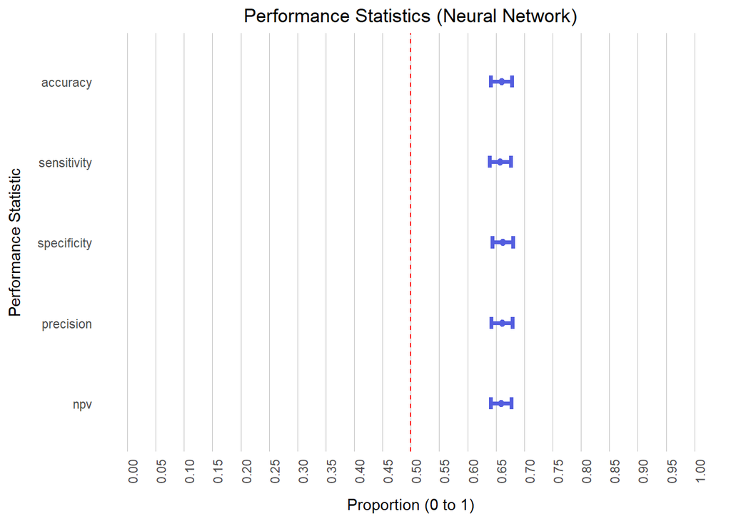

```r
# calculate average sample size
mean_n <- mean(results$n)

# create df to use for visualization
results_viz <-
  results %>%
  group_by(model_type) %>%
  summarize(accuracy = mean(accuracy),
            sensitivity = mean(sensitivity),
            specificity = mean(specificity),
            precision = mean(precision),
            npv = mean(npv)) %>%
  select(-model_type) %>%
  gather(key = "perf_stat",
         value = "value") %>%
  mutate(value = as.numeric(value))

# actual visualization
ggplot(data = results_viz,
  aes(x = perf_stat,
           y = value)) +
geom_point(size = 2,
           color = "#545EDF") +
geom_errorbar(aes(ymin = (value - 1.96*sqrt(value*(1-value)/mean_n)),
                   ymax = (value + 1.96*sqrt(value*(1-value)/mean_n))),
              color = "#545EDF",
              width = 0.15,
              size = 1.25) +
geom_hline(yintercept = 0.5,
           linetype = "dashed",
           size = 0.5,
           color = "red") +
scale_y_continuous(breaks = seq(from = 0, to = 1, by = 0.05),
                   limits = c(0, 1)) +
scale_x_discrete(limits = rev(c("accuracy", "sensitivity", "specificity",
                            "precision", "npv"))) +
coord_flip() +
theme(panel.grid.major.x = element_line(color = "grey",
                                        size = 0.25),
      panel.grid.minor.x = element_blank(),
      panel.grid.major.y = element_blank(),
      panel.background = element_blank(),
      axis.ticks = element_blank(),
      plot.title = element_text(hjust = 0.5),
      axis.title.y = element_text(margin =
                                    margin(t = 0, r = 10, b = 0, l = 0)),
      axis.title.x = element_text(margin =
                                    margin(t = 10, r = 00, b = 0, l = 0)),
      axis.text.x = element_text(angle = 90)) +
labs(title = "Performance Statistics (Neural Network)",
     x = "Performance Statistic",
     y = "Proportion (0 to 1)")
```

# Save Results

```r
# rename results df, to be particular to this model type (for disambiguation later)
results_neural <- results

# clear results variable
rm(results)

# save results in Rda file
save(results_neural,
     file = "results_neural.Rda")
```

# Render

If needed, I can render with rmarkdown::render(“hld_MODEL_svm.Rmd”).

# Citations

- Kuhn, M. (2008). Building predictive models in R using the caret package. Journal of Statistical Software, 28(5), 1-26.
- Kuhn, M., & Johnson, K. (2013). Applied predictive modeling (Vol. 26). Springer.
- McCulloch, W. S., & Pitts, W. (1943). A logical calculus of the ideas immanent in nervous activity. The Bulletin of Mathematical Biophysics, 5(4), 115-133.
- Ripley, B., & Venables, W. (2016). nnet: Feed-Forward Neural Networks and Multinomial Log-Linear Models (Version 7.3-12). Retrieved from https://CRAN.R-project.org/package=nnet
- Rosenblatt, F. (1958). The perceptron: a probabilistic model for information storage and organization in the brain. Psychological Review, 65(6), 386.
- McClelland, J. L., & Rumelhart, D. E. (1986). Parallel distributed processing. Explorations in the Microstructure of Cognition, 2, 216-271.